# Future directions

## Abstract

I was invited to an internal meeting on February 12, 2019 "to discuss Green Heron and review how Steve can help educate and train people on Green HERON. The goal is to review Steve’s examples and training material for investigators." This file will provide a very informal overview of my thoughts. The material I present is preliminary and I am very interested in your feedback.

## i2b2 Query & Analysis Tool

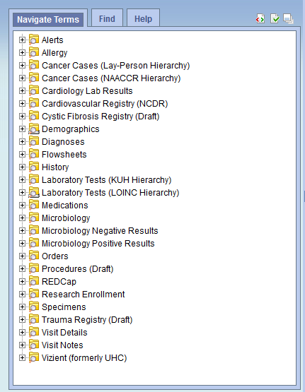

## i2b2 Query & Analysis Tool

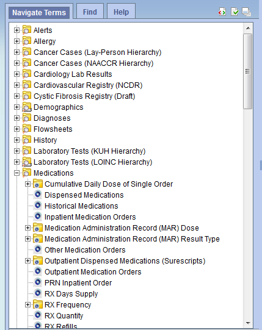

## i2b2 Query & Analysis Tool

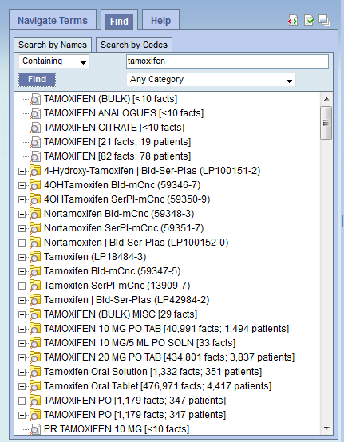

## i2b2 Query & Analysis Tool

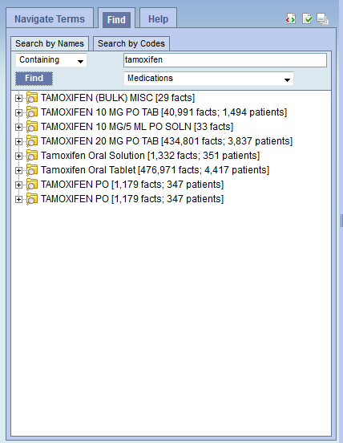

## Searching via metadata

```r
sql1 <- "
SELECT name_char FROM blueherondata.concept_dimension
WHERE concept_path LIKE '%Tamoxifen%'"
db1 <- dbGetQuery(c_connect, sql1)
db1 %>% sample_n(10)
```

```
##                                                 NAME_CHAR
## 7    Tamoxifen Oral Tablet [16,971 facts; 2,125 patients]
## 6                  TAMOXIFEN PO [510 facts; 219 patients]
## 2  Tamoxifen or aromatase inhibitor (AI) prescribed (ONC)
## 25                                  NOLVADEX 10 MG PO TAB
## 17                           Tamoxifen Bld-mCnc (59347-5)
## 13        4-Hydroxy-Tamoxifen | Bld-Ser-Plas (LP100151-2)
## 28               Nortamoxifen | Bld-Ser-Plas (LP100152-0)
## 18                         Tamoxifen SerPl-mCnc (13909-7)
## 26                           Endoxifen Bld-mCnc (59345-9)
## 8                                   NOLVADEX 20 MG PO TAB
```

## Advantages of i2b2 access

- Ease of use
- Hypothesis testing
- Well-focussed search

## Advantages of SQL access

- Data mining ("the process of finding anomalies, patterns and correlations within large data sets")
- Hypothesis generating
- Diverse search

## Examples of data mining applications

"A causal discovery method (McDSL) is adopted for causal discovery to infer true causal relationship between information buried in EHR (such as medication, diagnosis, laboratory tests, comorbidities and etc.) and Stage-3 AKI risk. The research approach comprised two major phases: data collection, and causal discovery. The first phase is propose to collect the data from HER (includes 358 encounters and 891 risk factors). Finally, McDSL is employed to discover the causal risk factors of Stage-3 AKI, and five well-known machine learning models are built for predicting Stage-3 AKI with 10-fold cross-validation (predictive accuracy were measured by AUC, precision, recall and F-score)."

- Chen et al. (2018)

Mei Liu and Xing Song have several publications that illustrate the value of a data mining approach to the electronic health record. We need to keep an annotated bibliography of references like this one.

## Special features of the data available through Green Heron

- Broad longitudinal coverage across many years
- Inclusion of billing data as well as clinical notes
- Linkage to various registries
- Other advantages?

## The heron-i2b2-analytics git repository.

[figure not shown]

## The heron-i2b2-analytics git repository.

The files and subdirectory structure loosely follow the recommendation in Wilson et al. (2017).

- README.md provides a general introduction and lists the tutorial programs.

## Bibliography

Chen, Weiqi, Yong Hu, Xiangzhou Zhang, Lijuan Wu, Kang Liu, Jianqin He, Zilin Tang, Xing Song, Lemuel R. Waitman, and Mei Liu. 2018. “Causal Risk Factor Discovery for Severe Acute Kidney Injury Using Electronic Health Records.” *BMC Medical Informatics and Decision Making* 18 (1): 13. doi:10.1186/s12911-018-0597-7.

Wilson, G., J. Bryan, K. Cranston, J. Kitzes, L. Nederbragt, and T. K. Teal. 2017. “Good enough practices in scientific computing.” *PLoS Comput. Biol.* 13 (6): e1005510.